# AppStoreProject

```python
import pandas as pd
pd.set_option('display.max_columns', None)

df_appstore1 = pd.read_csv('AppleStore1.csv')
df_appstore2 = pd.read_csv('AppleStore2.csv')
df_appstore3 = pd.read_csv('AppleStore3.csv')
df_appstore4 = pd.read_csv('AppleStore4.csv')
```

```python
df_appstore1.head()
```

|  | App Name | Size (bytes) | App id | Currency | Price | Rating (All) | Rating (Current) | Avg Rating (All) | Avy Rating (Current) | Version | Rating(Content) | Prefrence | Supp Devices | Screenshot | Supp Lang | Vpp Lic |
| --- | --- | --- | --- | --- | --- | --- | --- | --- | --- | --- | --- | --- | --- | --- | --- | --- |
| 0 | PAC-MAN Premium | 100788224 | 281656475 | USD | 3.99 | 21292 | 26 | 4.0 | 4.5 | 6.3.5 | 4+ | Games | 38 | 5 | 10 | 1 |
| 1 | Evernote - stay organized | 158578688 | 281796108 | USD | 0.00 | 161065 | 26 | 4.0 | 3.5 | 8.2.2 | 4+ | Productivity | 37 | 5 | 23 | 1 |
| 2 | WeatherBug - Local Weather, Radar, Maps, Alerts | 100524032 | 281940292 | USD | 0.00 | 188583 | 2822 | 3.5 | 4.5 | 5.0.0 | 4+ | Weather | 37 | 5 | 3 | 1 |
| 3 | eBay: Best App to Buy, Sell, Save! Online Shop... | 128512000 | 282614216 | USD | 0.00 | 262241 | 649 | 4.0 | 4.5 | 5.10.0 | 12+ | Shopping | 37 | 5 | 9 | 1 |
| 4 | Bible | 92774400 | 282935706 | USD | 0.00 | 985920 | 5320 | 4.5 | 5.0 | 7.5.1 | 4+ | Reference | 37 | 5 | 45 | 1 |

```python
df_appstore1.tail()
```

|  | App Name | Size (bytes) | App id | Currency | Price | Rating (All) | Rating (Current) | Avg Rating (All) | Avy Rating (Current) | Version | Rating(Content) | Prefrence | Supp Devices | Screenshot | Supp Lang | Vpp Lic |
| --- | --- | --- | --- | --- | --- | --- | --- | --- | --- | --- | --- | --- | --- | --- | --- | --- |
| 1795 | Second Grade Learning Games | 20853760 | 599694143 | USD | 2.99 | 322 | 13 | 4.5 | 5.0 | 2.6 | 4+ | Education | 37 | 5 | 1 | 1 |
| 1796 | School of Chaos Online MMORPG | 209825792 | 599852923 | USD | 0.00 | 5237 | 129 | 4.5 | 4.5 | 1.597 | 12+ | Games | 38 | 5 | 1 | 1 |
| 1797 | Minecraft: Papercraft Studio | 82397184 | 599955633 | USD | 2.99 | 1044 | 1 | 4.5 | 5.0 | 3.8.0 | 4+ | Games | 37 | 4 | 1 | 1 |
| 1798 | LGV Theory Test and Hazard Perception | 543456256 | 600093562 | USD | 9.99 | 0 | 0 | 0.0 | 0.0 | 10.2 | 4+ | Education | 37 | 5 | 1 | 1 |
| 1799 | Speakaboos Reading App: Stories & Songs for Kids | 76558336 | 600093661 | USD | 0.00 | 440 | 23 | 4.0 | 4.0 | 4.4.0 | 4+ | Education | 38 | 5 | 1 | 1 |

```python
df_appstore1.shape
```

```
(1800, 16)
```

```python
df_appstore2.head()
```

|  | App Name | Size (bytes) | App id | Currency | Price | Rating (All) | Rating (Current) | Avg Rating (All) | Avy Rating (Current) | Version | Rating(Content) | Prefrence | Supp Devices | Screenshot | Supp Lang | Vpp Lic |
| --- | --- | --- | --- | --- | --- | --- | --- | --- | --- | --- | --- | --- | --- | --- | --- | --- |
| 0 | 银联钱包- 银行卡管家，扫码支付享优惠 | 91323392 | 600273928 | USD | 0.00 | 9 | 1 | 3.5 | 3.0 | 4.5.3 | 17+ | Finance | 37 | 0 | 1 | 1 |
| 1 | Papa's Burgeria To Go! | 43646976 | 600626116 | USD | 0.99 | 570 | 5 | 4.5 | 4.0 | 1.1.2 | 4+ | Games | 37 | 0 | 16 | 1 |
| 2 | Pictoword: Fun 2 Pics Guess What's the Word Tr... | 126216192 | 600674056 | USD | 0.00 | 186089 | 1010 | 5.0 | 4.5 | 2.4.2 | 4+ | Games | 37 | 5 | 1 | 1 |
| 3 | SFind Premium Search for Spotify, YouTube & iT... | 8078336 | 601137830 | USD | 2.99 | 411 | 11 | 3.0 | 4.5 | 1.7 | 4+ | Entertainment | 40 | 2 | 15 | 1 |
| 4 | Junk Jack | 161118208 | 601584735 | USD | 4.99 | 6891 | 34 | 4.5 | 4.0 | 3.1 | 4+ | Games | 37 | 5 | 1 | 1 |

```python
df_appstore2.shape
```

```
(1800, 16)
```

```python
df_appstore3.head()
```

|  | App Name | Size (bytes) | App id | Currency | Price | Rating (All) | Rating (Current) | Avg Rating (All) | Avy Rating (Current) | Version | Rating(Content) | Prefrence | Supp Devices | Screenshot | Supp Lang | Vpp Lic |
| --- | --- | --- | --- | --- | --- | --- | --- | --- | --- | --- | --- | --- | --- | --- | --- | --- |
| 0 | Thumbly Keyboard | 60309504 | 978201325 | USD | 1.99 | 53 | 0 | 3.0 | 0.0 | 1.2.3 | 4+ | Utilities | 37 | 0 | 1 | 1 |
| 1 | WeicoPro 4 | 80967680 | 978236345 | USD | 0.99 | 106 | 0 | 3.0 | 0.0 | 4.9.12 | 17+ | Social Networking | 38 | 0 | 5 | 1 |
| 2 | Never Gone | 725459968 | 978238542 | USD | 0.00 | 87 | 6 | 4.0 | 4.0 | 1.1.4 | 12+ | Games | 37 | 5 | 6 | 1 |
| 3 | Sorcery! 3 | 332834816 | 978352903 | USD | 4.99 | 171 | 18 | 4.5 | 4.5 | 1.1.1 | 12+ | Games | 38 | 5 | 1 | 1 |
| 4 | Grim Fandango Remastered | 3521220608 | 978524071 | USD | 4.99 | 235 | 4 | 4.0 | 4.0 | 1.0.2 | 12+ | Games | 25 | 5 | 6 | 1 |

```python
df_appstore3.shape
```

```
(1800, 16)
```

```python
df_appstore4.head()
```

|  | App Name | Size (bytes) | App id | Currency | Price | Rating (All) | Rating (Current) | Avg Rating (All) | Avy Rating (Current) | Version | Rating(Content) | Prefrence | Supp Devices | Screenshot | Supp Lang | Vpp Lic |
| --- | --- | --- | --- | --- | --- | --- | --- | --- | --- | --- | --- | --- | --- | --- | --- | --- |
| 0 | CITB op/spec HS&E test 2016 | 24169472 | 1082673403 | USD | 5.99 | 0 | 0 | 0.0 | 0.0 | 3.0.17 | 12+ | Education | 37 | 5 | 1 | 1 |
| 1 | NEO TURF MASTERS | 53506048 | 1082674903 | USD | 2.99 | 96 | 38 | 4.5 | 4.5 | 1.0.1 | 4+ | Games | 38 | 5 | 10 | 1 |
| 2 | Pugmoji sticker keyboard by The BatPug | 61099008 | 1082678255 | USD | 1.99 | 76 | 22 | 3.5 | 2.5 | 1.0.3 | 4+ | Utilities | 37 | 0 | 1 | 1 |
| 3 | SkillTwins Football Game | 192502784 | 1082679672 | USD | 0.00 | 332 | 75 | 4.5 | 4.5 | 1.5 | 4+ | Games | 38 | 5 | 1 | 1 |
| 4 | Haunted Legends: The Secret of Life - A Myster... | 1317195776 | 1082764317 | USD | 6.99 | 69 | 15 | 4.5 | 5.0 | 1.0.2 | 9+ | Games | 37 | 5 | 5 | 1 |

```python
df_appstore4.tail()
```

|  | App Name | Size (bytes) | App id | Currency | Price | Rating (All) | Rating (Current) | Avg Rating (All) | Avy Rating (Current) | Version | Rating(Content) | Prefrence | Supp Devices | Screenshot | Supp Lang | Vpp Lic |
| --- | --- | --- | --- | --- | --- | --- | --- | --- | --- | --- | --- | --- | --- | --- | --- | --- |
| 1792 | Kubik | 126644224 | 1187617475 | USD | 0.00 | 142 | 75 | 4.5 | 4.5 | 1.3 | 4+ | Games | 38 | 5 | 1 | 1 |
| 1793 | VR Roller-Coaster | 120760320 | 1187682390 | USD | 0.00 | 30 | 30 | 4.5 | 4.5 | 0.9 | 4+ | Games | 38 | 0 | 1 | 1 |
| 1794 | Bret Michaels Emojis + Lyric Keyboard | 111322112 | 1187779532 | USD | 1.99 | 15 | 0 | 4.5 | 0.0 | 1.0.2 | 9+ | Utilities | 37 | 1 | 1 | 1 |
| 1795 | VR Roller Coaster World - Virtual Reality | 97235968 | 1187838770 | USD | 0.00 | 85 | 32 | 4.5 | 4.5 | 1.0.15 | 12+ | Games | 38 | 0 | 2 | 1 |
| 1796 | Escape the Sweet Shop Series | 90898432 | 1188375727 | USD | 0.00 | 3 | 3 | 5.0 | 5.0 | 1 | 4+ | Games | 40 | 0 | 2 | 1 |

```python
df_appstore4.shape
```

```
(1797, 16)
```

```python
df_appstore1.columns
```

```
Index(['App Name', 'Size (bytes)', 'App id', 'Currency', 'Price',
       'Rating (All)', 'Rating (Current)', 'Avg Rating (All)',
       'Avy Rating (Current)', 'Version', 'Rating(Content)', 'Prefrence',
       'Supp Devices', 'Screenshot', 'Supp Lang', 'Vpp Lic'],
      dtype='object')
```

```python
#merge columns using outer merge to retain alll the date
frames =[df_appstore1, df_appstore2, df_appstore3, df_appstore4]
df_merged = pd.concat(frames)
df_merged.head()
```

|  | App Name | Size (bytes) | App id | Currency | Price | Rating (All) | Rating (Current) | Avg Rating (All) | Avy Rating (Current) | Version | Rating(Content) | Prefrence | Supp Devices | Screenshot | Supp Lang | Vpp Lic |
| --- | --- | --- | --- | --- | --- | --- | --- | --- | --- | --- | --- | --- | --- | --- | --- | --- |
| 0 | PAC-MAN Premium | 100788224 | 281656475 | USD | 3.99 | 21292 | 26 | 4.0 | 4.5 | 6.3.5 | 4+ | Games | 38 | 5 | 10 | 1 |
| 1 | Evernote - stay organized | 158578688 | 281796108 | USD | 0.00 | 161065 | 26 | 4.0 | 3.5 | 8.2.2 | 4+ | Productivity | 37 | 5 | 23 | 1 |
| 2 | WeatherBug - Local Weather, Radar, Maps, Alerts | 100524032 | 281940292 | USD | 0.00 | 188583 | 2822 | 3.5 | 4.5 | 5.0.0 | 4+ | Weather | 37 | 5 | 3 | 1 |
| 3 | eBay: Best App to Buy, Sell, Save! Online Shop... | 128512000 | 282614216 | USD | 0.00 | 262241 | 649 | 4.0 | 4.5 | 5.10.0 | 12+ | Shopping | 37 | 5 | 9 | 1 |
| 4 | Bible | 92774400 | 282935706 | USD | 0.00 | 985920 | 5320 | 4.5 | 5.0 | 7.5.1 | 4+ | Reference | 37 | 5 | 45 | 1 |

```python
df_merged.tail()
```

|  | App Name | Size (bytes) | App id | Currency | Price | Rating (All) | Rating (Current) | Avg Rating (All) | Avy Rating (Current) | Version | Rating(Content) | Prefrence | Supp Devices | Screenshot | Supp Lang | Vpp Lic |
| --- | --- | --- | --- | --- | --- | --- | --- | --- | --- | --- | --- | --- | --- | --- | --- | --- |
| 1792 | Kubik | 126644224 | 1187617475 | USD | 0.00 | 142 | 75 | 4.5 | 4.5 | 1.3 | 4+ | Games | 38 | 5 | 1 | 1 |
| 1793 | VR Roller-Coaster | 120760320 | 1187682390 | USD | 0.00 | 30 | 30 | 4.5 | 4.5 | 0.9 | 4+ | Games | 38 | 0 | 1 | 1 |
| 1794 | Bret Michaels Emojis + Lyric Keyboard | 111322112 | 1187779532 | USD | 1.99 | 15 | 0 | 4.5 | 0.0 | 1.0.2 | 9+ | Utilities | 37 | 1 | 1 | 1 |
| 1795 | VR Roller Coaster World - Virtual Reality | 97235968 | 1187838770 | USD | 0.00 | 85 | 32 | 4.5 | 4.5 | 1.0.15 | 12+ | Games | 38 | 0 | 2 | 1 |
| 1796 | Escape the Sweet Shop Series | 90898432 | 1188375727 | USD | 0.00 | 3 | 3 | 5.0 | 5.0 | 1 | 4+ | Games | 40 | 0 | 2 | 1 |

```python
df_merged.shape
```

```
(7197, 16)
```

```python
#Now that we have merged the datasets we can continue to treat missing values
```

```python
dup_rows = df_merged.duplicated()
print(dup_rows)
```

```
0       False
1       False
2       False
3       False
4       False
        ...
1792    False
1793    False
1794    False
1795    False
1796    False
Length: 7197, dtype: bool
```

```python
missing_values = df_merged.isna().sum()
print(missing_values)
```

```
App Name                0
Size (bytes)            0
App id                  0
Currency                0
Price                   0
Rating (All)            0
Rating (Current)        0
Avg Rating (All)        0
Avy Rating (Current)    0
Version                 0
Rating(Content)         0
Prefrence               0
Supp Devices            0
Screenshot              0
Supp Lang               0
Vpp Lic                 0
dtype: int64
```

```python
#drop columns that we are not going to use
df_merged.drop(columns=["Version"], inplace = True)
```

```python
df_merged.columns
```

```
Index(['App Name', 'Size (bytes)', 'App id', 'Currency', 'Price',
       'Rating (All)', 'Rating (Current)', 'Avg Rating (All)',
       'Avy Rating (Current)', 'Rating(Content)', 'Prefrence', 'Supp Devices',
       'Screenshot', 'Supp Lang', 'Vpp Lic'],
      dtype='object')
```

```python
df_merged.rename(columns ={'Prefrence':'Preference'}, inplace = True)
df_merged.rename(columns ={'Avy Rating (Current)':'Avg Rating (Current)'}, inplace = True)
df_merged.columns
```

```
Index(['App Name', 'Size (bytes)', 'App id', 'Currency', 'Price',
       'Rating (All)', 'Rating (Current)', 'Avg Rating (All)',
       'Avg Rating (Current)', 'Rating(Content)', 'Preference', 'Supp Devices',
       'Screenshot', 'Supp Lang', 'Vpp Lic'],
      dtype='object')
```

```python
df_merged.dtypes
```

```
App Name                 object
Size (bytes)              int64
App id                    int64
Currency                 object
Price                   float64
Rating (All)              int64
Rating (Current)          int64
Avg Rating (All)        float64
Avg Rating (Current)    float64
Rating(Content)          object
Preference               object
Supp Devices              int64
Screenshot                int64
Supp Lang                 int64
Vpp Lic                   int64
dtype: object
```

```python
import re

# Function to remove special characters from a string
def rem_spec_char(text):
    return re.sub(r'[^a-zA-Z0-9\s]+', '', text)


df_merged['App Name'] = df_merged['App Name'].apply(rem_spec_char)
```

```python
df_merged.head()
```

|  | App Name | Size (bytes) | App id | Currency | Price | Rating (All) | Rating (Current) | Avg Rating (All) | Avg Rating (Current) | Rating(Content) | Preference | Supp Devices | Screenshot | Supp Lang | Vpp Lic |
| --- | --- | --- | --- | --- | --- | --- | --- | --- | --- | --- | --- | --- | --- | --- | --- |
| 0 | PACMAN Premium | 100788224 | 281656475 | USD | 3.99 | 21292 | 26 | 4.0 | 4.5 | 4+ | Games | 38 | 5 | 10 | 1 |
| 1 | Evernote stay organized | 158578688 | 281796108 | USD | 0.00 | 161065 | 26 | 4.0 | 3.5 | 4+ | Productivity | 37 | 5 | 23 | 1 |
| 2 | WeatherBug Local Weather Radar Maps Alerts | 100524032 | 281940292 | USD | 0.00 | 188583 | 2822 | 3.5 | 4.5 | 4+ | Weather | 37 | 5 | 3 | 1 |
| 3 | eBay Best App to Buy Sell Save Online Shopping | 128512000 | 282614216 | USD | 0.00 | 262241 | 649 | 4.0 | 4.5 | 12+ | Shopping | 37 | 5 | 9 | 1 |
| 4 | Bible | 92774400 | 282935706 | USD | 0.00 | 985920 | 5320 | 4.5 | 5.0 | 4+ | Reference | 37 | 5 | 45 | 1 |

```python
df_merged.tail()
```

|  | App Name | Size (bytes) | App id | Currency | Price | Rating (All) | Rating (Current) | Avg Rating (All) | Avg Rating (Current) | Rating(Content) | Preference | Supp Devices | Screenshot | Supp Lang | Vpp Lic |
| --- | --- | --- | --- | --- | --- | --- | --- | --- | --- | --- | --- | --- | --- | --- | --- |
| 1792 | Kubik | 126644224 | 1187617475 | USD | 0.00 | 142 | 75 | 4.5 | 4.5 | 4+ | Games | 38 | 5 | 1 | 1 |
| 1793 | VR RollerCoaster | 120760320 | 1187682390 | USD | 0.00 | 30 | 30 | 4.5 | 4.5 | 4+ | Games | 38 | 0 | 1 | 1 |
| 1794 | Bret Michaels Emojis Lyric Keyboard | 111322112 | 1187779532 | USD | 1.99 | 15 | 0 | 4.5 | 0.0 | 9+ | Utilities | 37 | 1 | 1 | 1 |
| 1795 | VR Roller Coaster World Virtual Reality | 97235968 | 1187838770 | USD | 0.00 | 85 | 32 | 4.5 | 4.5 | 12+ | Games | 38 | 0 | 2 | 1 |
| 1796 | Escape the Sweet Shop Series | 90898432 | 1188375727 | USD | 0.00 | 3 | 3 | 5.0 | 5.0 | 4+ | Games | 40 | 0 | 2 | 1 |

```python
def bytes_to_megabytes(bytes):
    return bytes / (1024 * 1024)

df_merged['Size (MB)'] = round(df_merged['Size (bytes)'].apply(bytes_to_megabytes))

df_merged.head()
```

|  | App Name | Size (bytes) | App id | Currency | Price | Rating (All) | Rating (Current) | Avg Rating (All) | Avg Rating (Current) | Rating(Content) | Preference | Supp Devices | Screenshot | Supp Lang | Vpp Lic | Size (MB) |
| --- | --- | --- | --- | --- | --- | --- | --- | --- | --- | --- | --- | --- | --- | --- | --- | --- |
| 0 | PACMAN Premium | 100788224 | 281656475 | USD | 3.99 | 21292 | 26 | 4.0 | 4.5 | 4+ | Games | 38 | 5 | 10 | 1 | 96.0 |
| 1 | Evernote stay organized | 158578688 | 281796108 | USD | 0.00 | 161065 | 26 | 4.0 | 3.5 | 4+ | Productivity | 37 | 5 | 23 | 1 | 151.0 |
| 2 | WeatherBug Local Weather Radar Maps Alerts | 100524032 | 281940292 | USD | 0.00 | 188583 | 2822 | 3.5 | 4.5 | 4+ | Weather | 37 | 5 | 3 | 1 | 96.0 |
| 3 | eBay Best App to Buy Sell Save Online Shopping | 128512000 | 282614216 | USD | 0.00 | 262241 | 649 | 4.0 | 4.5 | 12+ | Shopping | 37 | 5 | 9 | 1 | 123.0 |
| 4 | Bible | 92774400 | 282935706 | USD | 0.00 | 985920 | 5320 | 4.5 | 5.0 | 4+ | Reference | 37 | 5 | 45 | 1 | 88.0 |

```python
#Summary Statistics for the price
med_price = df_merged['Price'].median()
mean_price = df_merged['Price'].mean()
print("Median Price:", med_price, 'USD')
print("Average Price:", round(mean_price ,2),'USD')
```

```
Median Price: 0.0 USD
Average Price: 1.73 USD
```

```python
#Summary Statistics for Supp Devices
avg_supp_dev = df_merged['Supp Devices'].mean()
print("Average supported devices: ", round(avg_supp_dev))
```

```
Average supported devices:  37
```

```python
#Summary Statistics for supported languages
avg_supp_lang = df_merged['Supp Lang'].mean()
print("Average number of supported languages:", round(avg_supp_lang))
```

```
Average number of supported languages: 5
```

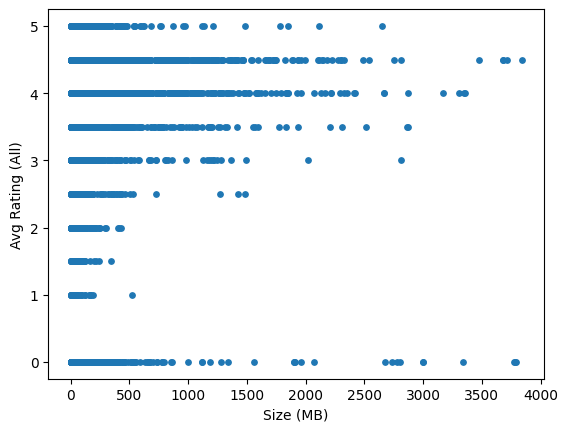

```python
df_merged.plot.scatter(x='Size (MB)', y='Avg Rating (All)', s=15)
```

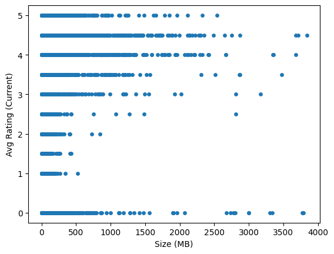

```python
df_merged.plot.scatter(x='Size (MB)', y='Avg Rating (Current)', s=15)
```

### The concentration of data points across the higher end of the axis could indicate that many app are well received by the users.

### There appears to be more variability in average ratings for smaller-sized apps compared to larger ones. This could be influenced by various other factors like user friendliness and functionality.

### There also appears to be fewer data points across the higher end of the axis for larger sized apps, this shows that although apps could be learger it does not necessarily translate to it having a higher average rating.

### There doesn't seem to be a difference in concentration and density in the scatter plots that compare the size and average ratings.

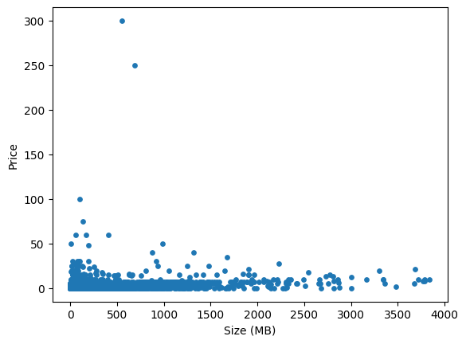

```python
df_merged.plot.scatter(x='Size (MB)', y='Price', s=15)
```

### From this scatter plot, it can be noted that there is no clear relationship between price and size of the application. There isn't a notieable trend.

### It seems that most of the data points cluster towards the lower end of both axes, indicating that the majority of apps have relatively smaller sizes and lower prices.

### There are fewer data points towards the higher end of the axis, meaning that the market for higher priced apps is not saturated.

```python
avg_rating_all = df_merged['Avg Rating (All)']
type(avg_rating_all)
```

```
pandas.core.series.Series
```

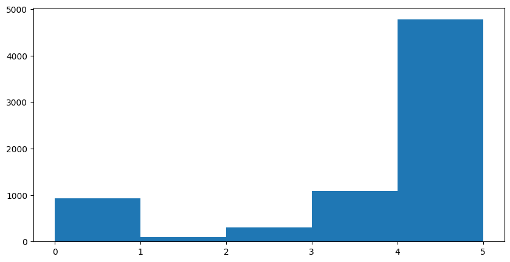

```python
import matplotlib.pyplot as plt

plt.figure(figsize = (10, 5))
plt.hist(avg_rating_all, bins = 5)
plt.show()
```

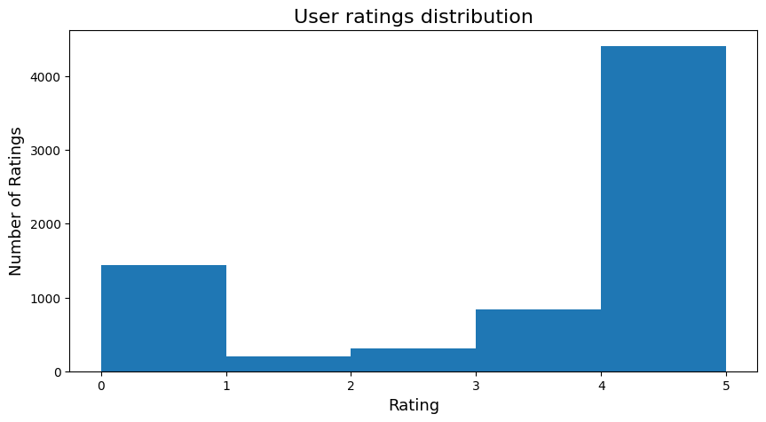

```python
avg_rating_curr = df_merged['Avg Rating (Current)']

plt.figure(figsize = (10, 5))
plt.hist(avg_rating_curr, bins = 5)
plt.title("User ratings distribution", fontsize = 16)
plt.ylabel("Number of Ratings", fontsize = 13)
plt.xlabel("Rating", fontsize = 13)
plt.show()
```

### On the current version of the applications on the AppStore a concern should be noted with a significant increase of app ratings = 0.

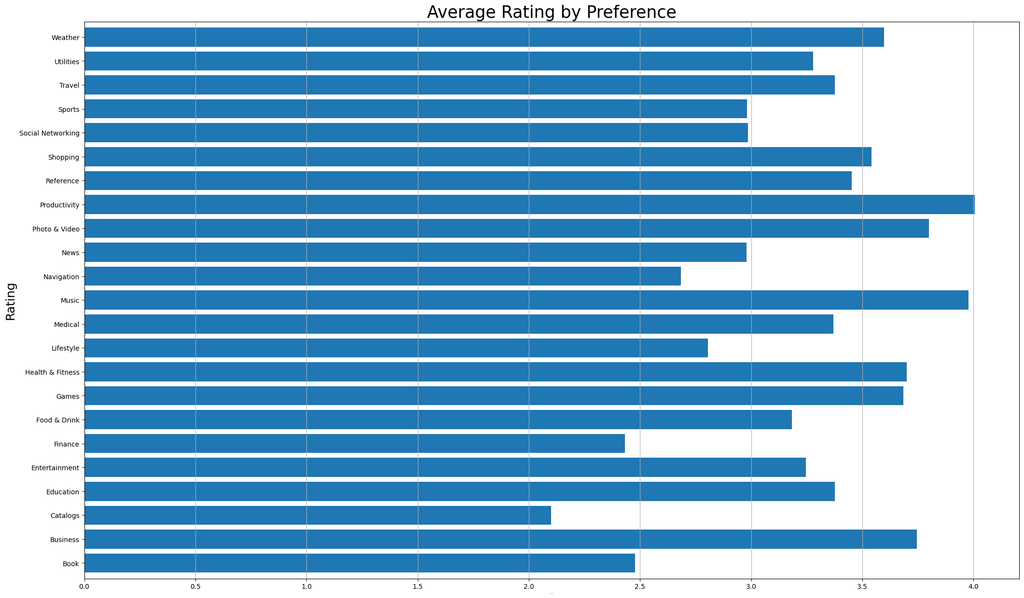

```python
grouped_data = df_merged.groupby('Preference')['Avg Rating (All)'].mean()
grouped_data.plot(kind='barh', figsize=(25, 15), width = 0.8)
plt.xlabel('Preference', fontsize = 1)
plt.ylabel('Rating', fontsize = 18)
plt.title('Average Rating by Preference', fontsize = 25)
plt.xticks(rotation=0)
plt.grid(True, axis = 'x')
plt.show()
```

```python
df_merged.info()
```

```
<class 'pandas.core.frame.DataFrame'>
Index: 7197 entries, 0 to 1796
Data columns (total 16 columns):
 #   Column                Non-Null Count  Dtype
---  ------                --------------  -----
 0   App Name              7197 non-null   object
 1   Size (bytes)          7197 non-null   int64
 2   App id                7197 non-null   int64
 3   Currency              7197 non-null   object
 4   Price                 7197 non-null   float64
 5   Rating (All)          7197 non-null   int64
 6   Rating (Current)      7197 non-null   int64
 7   Avg Rating (All)      7197 non-null   float64
 8   Avg Rating (Current)  7197 non-null   float64
 9   Rating(Content)       7197 non-null   object
 10  Preference            7197 non-null   object
 11  Supp Devices          7197 non-null   int64
 12  Screenshot            7197 non-null   int64
 13  Supp Lang             7197 non-null   int64
 14  Vpp Lic               7197 non-null   int64
 15  Size (MB)             7197 non-null   float64
dtypes: float64(4), int64(8), object(4)
memory usage: 955.9+ KB
```

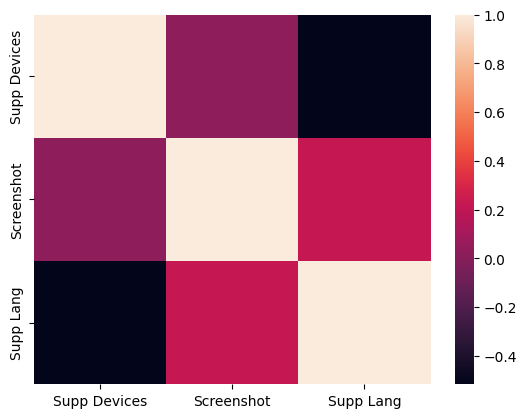

```python
import seaborn as sns
df_grp_data = df_merged.groupby('Preference')[['Supp Devices', 'Screenshot', 'Supp Lang']].mean()
sns.heatmap(df_grp_data.corr())
```

### The data is grouped by 'Preference', the correlations may vary across different preference categories. This will be investigated further in the next figure

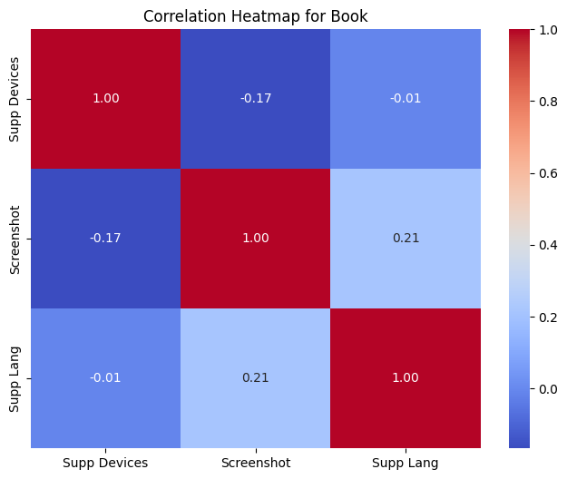

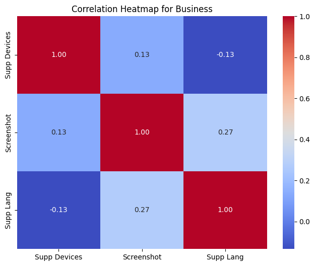

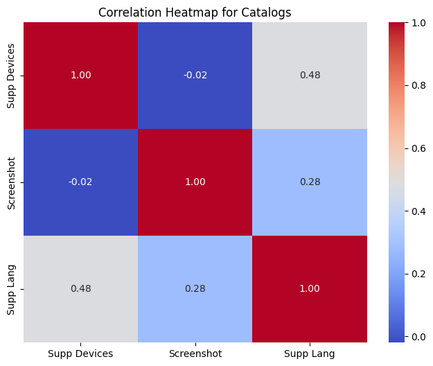

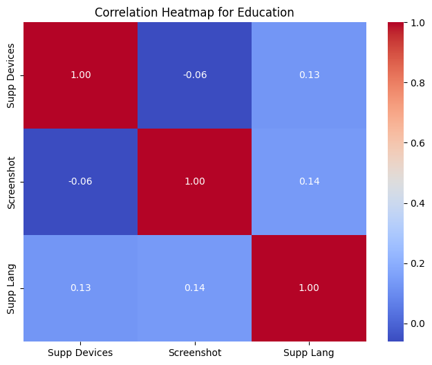

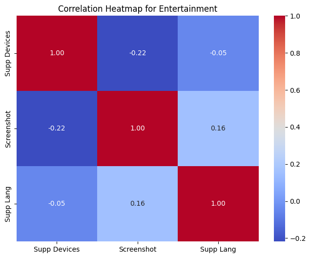

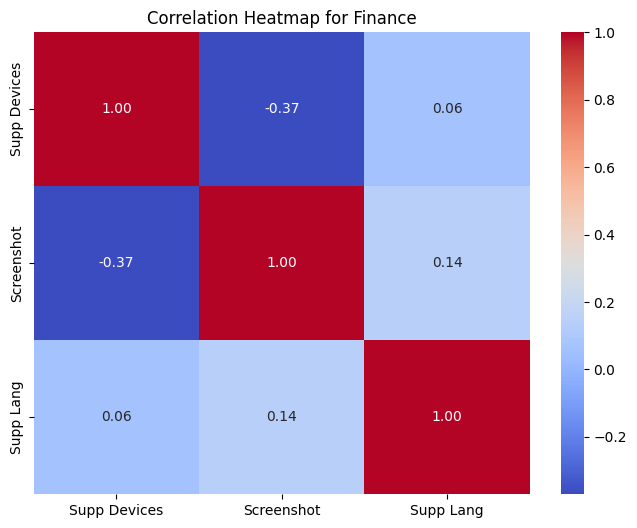

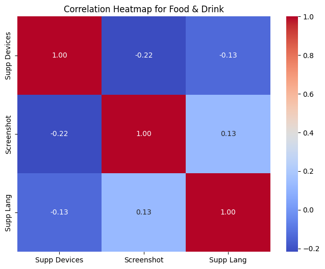

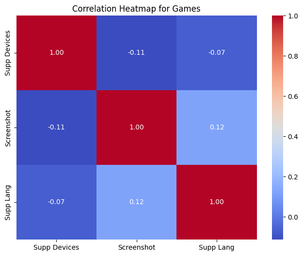

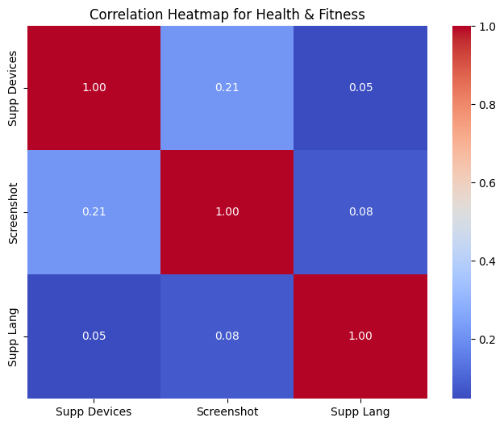

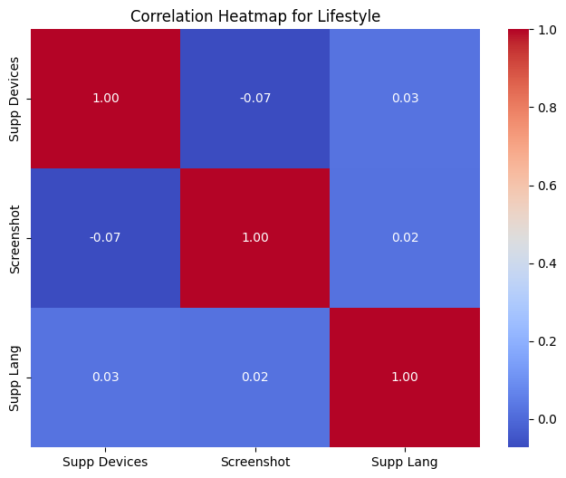

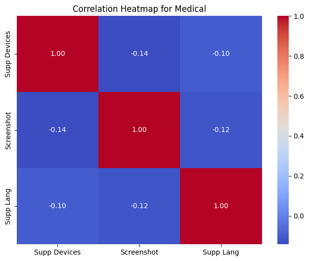

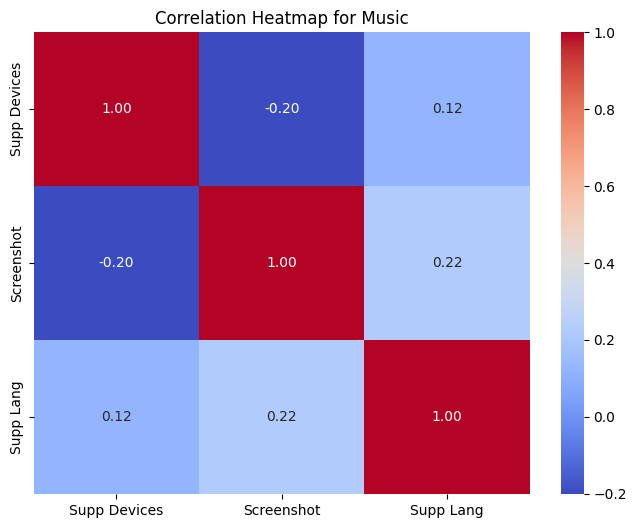

[11 more figures not shown]

```python
grouped_data = df_merged.groupby('Preference')

# Loop through each group
for group_name, group_data in grouped_data:
    # Calculate correlation matrix for the group
    corr_matrix = group_data[['Supp Devices', 'Screenshot', 'Supp Lang']].corr()

    # Plot heatmap for the correlation matrix
    plt.figure(figsize=(8, 6))
    sns.heatmap(corr_matrix, annot=True, cmap='coolwarm', fmt=".2f")
    plt.title(f'Correlation Heatmap for {group_name}')
    plt.show()
```

### Upon investigating this further to a granular level, it can be seen that the data shows no clear pattern or trend, with significant variability observed across various app categories

### In some cases there is a moderate relationship between supported languages and screenshot.

```python
df_grp_data = df_merged.groupby('Preference')[['Supp Devices', 'Screenshot', 'Supp Lang']].mean()
df_grp_data
```

| Preference | Supp Devices | Screenshot | Supp Lang |
| --- | --- | --- | --- |
| Book | 37.544643 | 2.991071 | 2.375000 |
| Business | 36.122807 | 3.368421 | 10.684211 |
| Catalogs | 37.300000 | 3.400000 | 2.400000 |
| Education | 36.675497 | 4.421634 | 7.205298 |
| Entertainment | 36.671028 | 3.050467 | 4.528972 |
| Finance | 36.836538 | 1.721154 | 2.250000 |
| Food & Drink | 36.920635 | 2.063492 | 3.571429 |
| Games | 38.018384 | 4.298032 | 4.587778 |
| Health & Fitness | 35.888889 | 2.450000 | 6.661111 |
| Lifestyle | 37.069444 | 1.847222 | 4.777778 |
| Medical | 36.652174 | 3.173913 | 3.695652 |
| Music | 35.471014 | 3.637681 | 7.137681 |
| Navigation | 36.239130 | 2.565217 | 6.000000 |
| News | 36.560000 | 2.760000 | 2.880000 |
| Photo & Video | 36.756447 | 2.957020 | 9.664756 |
| Productivity | 36.039326 | 3.808989 | 11.050562 |
| Reference | 36.562500 | 3.906250 | 5.437500 |
| Shopping | 36.622951 | 2.172131 | 3.770492 |
| Social Networking | 36.520958 | 1.742515 | 9.125749 |
| Sports | 36.921053 | 3.000000 | 4.140351 |
| Travel | 37.012346 | 2.592593 | 7.592593 |
| Utilities | 36.685484 | 2.725806 | 6.520161 |
| Weather | 36.652778 | 3.125000 | 7.319444 |

[figure not shown]

```python
binary_counts = df_merged['Vpp Lic'].value_counts()

fig, ax = plt.subplots(figsize=(8, 6))
binary_counts.plot(kind='bar', ax=ax, color=['blue', 'orange'])
ax.set_title('Occurrence of 0s and 1s')
ax.set_xlabel('Value')
ax.set_ylabel('Count')
ax.set_xticklabels(['0', '1'], rotation=0)

plt.show()
```